# Risk Factor Analysis

## Outcome Variable

**Outcome Variable:** ever_stunted

## Predictor Variables

**Intervention Variable:** mbmi

**Adjustment Set:**

unadjusted

## Stratifying Variables

The analysis was stratified on these variable(s):

- agecat
- studyid
- country

## Data Summary

| agecat | studyid | country | A | n | nA | nAY0 | nAY1 |
| --- | --- | --- | --- | --- | --- | --- | --- |
| 3 months | ki0047075b-MAL-ED | BANGLADESH | [18.5-25) | 254 | 163 | 118 | 45 |
| 3 months | ki0047075b-MAL-ED | BANGLADESH | <18.5 | 254 | 32 | 20 | 12 |
| 3 months | ki0047075b-MAL-ED | BANGLADESH | [25-30) | 254 | 53 | 42 | 11 |
| 3 months | ki0047075b-MAL-ED | BANGLADESH | >=30 | 254 | 6 | 2 | 4 |
| 3 months | ki0047075b-MAL-ED | BRAZIL | [18.5-25) | 221 | 88 | 77 | 11 |
| 3 months | ki0047075b-MAL-ED | BRAZIL | <18.5 | 221 | 10 | 7 | 3 |
| 3 months | ki0047075b-MAL-ED | BRAZIL | [25-30) | 221 | 82 | 69 | 13 |
| 3 months | ki0047075b-MAL-ED | BRAZIL | >=30 | 221 | 41 | 34 | 7 |
| 3 months | ki0047075b-MAL-ED | INDIA | [18.5-25) | 242 | 142 | 103 | 39 |
| 3 months | ki0047075b-MAL-ED | INDIA | <18.5 | 242 | 49 | 35 | 14 |
| 3 months | ki0047075b-MAL-ED | INDIA | [25-30) | 242 | 40 | 30 | 10 |
| 3 months | ki0047075b-MAL-ED | INDIA | >=30 | 242 | 11 | 9 | 2 |
| 3 months | ki0047075b-MAL-ED | NEPAL | [18.5-25) | 238 | 134 | 114 | 20 |
| 3 months | ki0047075b-MAL-ED | NEPAL | <18.5 | 238 | 0 | 0 | 0 |
| 3 months | ki0047075b-MAL-ED | NEPAL | [25-30) | 238 | 87 | 74 | 13 |
| 3 months | ki0047075b-MAL-ED | NEPAL | >=30 | 238 | 17 | 13 | 4 |
| 3 months | ki0047075b-MAL-ED | PERU | [18.5-25) | 290 | 159 | 99 | 60 |
| 3 months | ki0047075b-MAL-ED | PERU | <18.5 | 290 | 5 | 3 | 2 |
| 3 months | ki0047075b-MAL-ED | PERU | [25-30) | 290 | 109 | 77 | 32 |
| 3 months | ki0047075b-MAL-ED | PERU | >=30 | 290 | 17 | 11 | 6 |
| 3 months | ki0047075b-MAL-ED | SOUTH AFRICA | [18.5-25) | 270 | 109 | 72 | 37 |
| 3 months | ki0047075b-MAL-ED | SOUTH AFRICA | <18.5 | 270 | 8 | 6 | 2 |
| 3 months | ki0047075b-MAL-ED | SOUTH AFRICA | [25-30) | 270 | 87 | 62 | 25 |
| 3 months | ki0047075b-MAL-ED | SOUTH AFRICA | >=30 | 270 | 66 | 58 | 8 |
| 3 months | ki0047075b-MAL-ED | TANZANIA, UNITED REPUBLIC OF | [18.5-25) | 256 | 177 | 121 | 56 |
| 3 months | ki0047075b-MAL-ED | TANZANIA, UNITED REPUBLIC OF | <18.5 | 256 | 14 | 7 | 7 |
| 3 months | ki0047075b-MAL-ED | TANZANIA, UNITED REPUBLIC OF | [25-30) | 256 | 53 | 37 | 16 |
| 3 months | ki0047075b-MAL-ED | TANZANIA, UNITED REPUBLIC OF | >=30 | 256 | 12 | 10 | 2 |
| 3 months | ki1000304b-SAS-CompFeed | INDIA | [18.5-25) | 417 | 285 | 190 | 95 |
| 3 months | ki1000304b-SAS-CompFeed | INDIA | <18.5 | 417 | 111 | 67 | 44 |

[output cut: 278 more lines]

The following strata were considered:

- agecat: 12 months, studyid: ki0047075b-MAL-ED, country: BANGLADESH
- agecat: 12 months, studyid: ki0047075b-MAL-ED, country: BRAZIL
- agecat: 12 months, studyid: ki0047075b-MAL-ED, country: INDIA
- agecat: 12 months, studyid: ki0047075b-MAL-ED, country: NEPAL
- agecat: 12 months, studyid: ki0047075b-MAL-ED, country: PERU
- agecat: 12 months, studyid: ki0047075b-MAL-ED, country: SOUTH AFRICA
- agecat: 12 months, studyid: ki0047075b-MAL-ED, country: TANZANIA, UNITED REPUBLIC OF
- agecat: 12 months, studyid: ki1000304b-SAS-CompFeed, country: INDIA
- agecat: 12 months, studyid: ki1017093-NIH-Birth, country: BANGLADESH
- agecat: 12 months, studyid: ki1017093b-PROVIDE, country: BANGLADESH
- agecat: 12 months, studyid: ki1017093c-NIH-Crypto, country: BANGLADESH
- agecat: 12 months, studyid: ki1066203-TanzaniaChild2, country: TANZANIA, UNITED REPUBLIC OF
- agecat: 12 months, studyid: ki1112895-iLiNS-Zinc, country: BURKINA FASO
- agecat: 12 months, studyid: ki1119695-PROBIT, country: BELARUS
- agecat: 12 months, studyid: ki1126311-ZVITAMBO, country: ZIMBABWE
- agecat: 12 months, studyid: ki1148112-LCNI-5, country: MALAWI
- agecat: 18 months, studyid: ki0047075b-MAL-ED, country: BANGLADESH
- agecat: 18 months, studyid: ki0047075b-MAL-ED, country: BRAZIL
- agecat: 18 months, studyid: ki0047075b-MAL-ED, country: INDIA
- agecat: 18 months, studyid: ki0047075b-MAL-ED, country: NEPAL
- agecat: 18 months, studyid: ki0047075b-MAL-ED, country: PERU
- agecat: 18 months, studyid: ki0047075b-MAL-ED, country: SOUTH AFRICA
- agecat: 18 months, studyid: ki0047075b-MAL-ED, country: TANZANIA, UNITED REPUBLIC OF
- agecat: 18 months, studyid: ki1000304b-SAS-CompFeed, country: INDIA
- agecat: 18 months, studyid: ki1017093-NIH-Birth, country: BANGLADESH
- agecat: 18 months, studyid: ki1017093b-PROVIDE, country: BANGLADESH
- agecat: 18 months, studyid: ki1017093c-NIH-Crypto, country: BANGLADESH
- agecat: 18 months, studyid: ki1066203-TanzaniaChild2, country: TANZANIA, UNITED REPUBLIC OF
- agecat: 18 months, studyid: ki1112895-iLiNS-Zinc, country: BURKINA FASO
- agecat: 18 months, studyid: ki1119695-PROBIT, country: BELARUS
- agecat: 18 months, studyid: ki1126311-ZVITAMBO, country: ZIMBABWE
- agecat: 18 months, studyid: ki1148112-LCNI-5, country: MALAWI
- agecat: 24 months, studyid: ki0047075b-MAL-ED, country: BANGLADESH
- agecat: 24 months, studyid: ki0047075b-MAL-ED, country: BRAZIL
- agecat: 24 months, studyid: ki0047075b-MAL-ED, country: INDIA
- agecat: 24 months, studyid: ki0047075b-MAL-ED, country: NEPAL
- agecat: 24 months, studyid: ki0047075b-MAL-ED, country: PERU
- agecat: 24 months, studyid: ki0047075b-MAL-ED, country: SOUTH AFRICA
- agecat: 24 months, studyid: ki0047075b-MAL-ED, country: TANZANIA, UNITED REPUBLIC OF
- agecat: 24 months, studyid: ki1000304b-SAS-CompFeed, country: INDIA
- agecat: 24 months, studyid: ki1017093-NIH-Birth, country: BANGLADESH
- agecat: 24 months, studyid: ki1017093b-PROVIDE, country: BANGLADESH
- agecat: 24 months, studyid: ki1017093c-NIH-Crypto, country: BANGLADESH
- agecat: 24 months, studyid: ki1066203-TanzaniaChild2, country: TANZANIA, UNITED REPUBLIC OF
- agecat: 24 months, studyid: ki1112895-iLiNS-Zinc, country: BURKINA FASO
- agecat: 24 months, studyid: ki1119695-PROBIT, country: BELARUS
- agecat: 24 months, studyid: ki1126311-ZVITAMBO, country: ZIMBABWE
- agecat: 24 months, studyid: ki1148112-LCNI-5, country: MALAWI
- agecat: 3 months, studyid: ki0047075b-MAL-ED, country: BANGLADESH
- agecat: 3 months, studyid: ki0047075b-MAL-ED, country: BRAZIL
- agecat: 3 months, studyid: ki0047075b-MAL-ED, country: INDIA
- agecat: 3 months, studyid: ki0047075b-MAL-ED, country: NEPAL
- agecat: 3 months, studyid: ki0047075b-MAL-ED, country: PERU
- agecat: 3 months, studyid: ki0047075b-MAL-ED, country: SOUTH AFRICA
- agecat: 3 months, studyid: ki0047075b-MAL-ED, country: TANZANIA, UNITED REPUBLIC OF
- agecat: 3 months, studyid: ki1000304b-SAS-CompFeed, country: INDIA
- agecat: 3 months, studyid: ki1017093-NIH-Birth, country: BANGLADESH
- agecat: 3 months, studyid: ki1017093b-PROVIDE, country: BANGLADESH
- agecat: 3 months, studyid: ki1017093c-NIH-Crypto, country: BANGLADESH
- agecat: 3 months, studyid: ki1066203-TanzaniaChild2, country: TANZANIA, UNITED REPUBLIC OF
- agecat: 3 months, studyid: ki1119695-PROBIT, country: BELARUS
- agecat: 3 months, studyid: ki1126311-ZVITAMBO, country: ZIMBABWE
- agecat: 6 months, studyid: ki0047075b-MAL-ED, country: BANGLADESH
- agecat: 6 months, studyid: ki0047075b-MAL-ED, country: BRAZIL
- agecat: 6 months, studyid: ki0047075b-MAL-ED, country: INDIA
- agecat: 6 months, studyid: ki0047075b-MAL-ED, country: NEPAL
- agecat: 6 months, studyid: ki0047075b-MAL-ED, country: PERU
- agecat: 6 months, studyid: ki0047075b-MAL-ED, country: SOUTH AFRICA
- agecat: 6 months, studyid: ki0047075b-MAL-ED, country: TANZANIA, UNITED REPUBLIC OF
- agecat: 6 months, studyid: ki1000304b-SAS-CompFeed, country: INDIA
- agecat: 6 months, studyid: ki1017093-NIH-Birth, country: BANGLADESH
- agecat: 6 months, studyid: ki1017093b-PROVIDE, country: BANGLADESH
- agecat: 6 months, studyid: ki1017093c-NIH-Crypto, country: BANGLADESH
- agecat: 6 months, studyid: ki1066203-TanzaniaChild2, country: TANZANIA, UNITED REPUBLIC OF
- agecat: 6 months, studyid: ki1119695-PROBIT, country: BELARUS
- agecat: 6 months, studyid: ki1126311-ZVITAMBO, country: ZIMBABWE
- agecat: 6 months, studyid: ki1148112-LCNI-5, country: MALAWI

### Dropped Strata

Some strata were dropped due to rare outcomes:

- agecat: 3 months, studyid: ki0047075b-MAL-ED, country: BANGLADESH
- agecat: 3 months, studyid: ki0047075b-MAL-ED, country: BRAZIL
- agecat: 3 months, studyid: ki0047075b-MAL-ED, country: INDIA
- agecat: 3 months, studyid: ki0047075b-MAL-ED, country: NEPAL
- agecat: 3 months, studyid: ki0047075b-MAL-ED, country: PERU
- agecat: 3 months, studyid: ki0047075b-MAL-ED, country: SOUTH AFRICA
- agecat: 3 months, studyid: ki0047075b-MAL-ED, country: TANZANIA, UNITED REPUBLIC OF
- agecat: 3 months, studyid: ki1000304b-SAS-CompFeed, country: INDIA
- agecat: 3 months, studyid: ki1017093-NIH-Birth, country: BANGLADESH
- agecat: 3 months, studyid: ki1017093b-PROVIDE, country: BANGLADESH
- agecat: 3 months, studyid: ki1017093c-NIH-Crypto, country: BANGLADESH
- agecat: 6 months, studyid: ki0047075b-MAL-ED, country: BANGLADESH
- agecat: 6 months, studyid: ki0047075b-MAL-ED, country: BRAZIL
- agecat: 6 months, studyid: ki0047075b-MAL-ED, country: INDIA
- agecat: 6 months, studyid: ki0047075b-MAL-ED, country: NEPAL
- agecat: 6 months, studyid: ki0047075b-MAL-ED, country: PERU
- agecat: 6 months, studyid: ki0047075b-MAL-ED, country: SOUTH AFRICA
- agecat: 6 months, studyid: ki0047075b-MAL-ED, country: TANZANIA, UNITED REPUBLIC OF
- agecat: 6 months, studyid: ki1000304b-SAS-CompFeed, country: INDIA
- agecat: 6 months, studyid: ki1017093-NIH-Birth, country: BANGLADESH
- agecat: 6 months, studyid: ki1017093b-PROVIDE, country: BANGLADESH
- agecat: 6 months, studyid: ki1148112-LCNI-5, country: MALAWI
- agecat: 12 months, studyid: ki0047075b-MAL-ED, country: BANGLADESH
- agecat: 12 months, studyid: ki0047075b-MAL-ED, country: BRAZIL
- agecat: 12 months, studyid: ki0047075b-MAL-ED, country: INDIA
- agecat: 12 months, studyid: ki0047075b-MAL-ED, country: NEPAL
- agecat: 12 months, studyid: ki0047075b-MAL-ED, country: PERU
- agecat: 12 months, studyid: ki0047075b-MAL-ED, country: SOUTH AFRICA
- agecat: 12 months, studyid: ki0047075b-MAL-ED, country: TANZANIA, UNITED REPUBLIC OF
- agecat: 12 months, studyid: ki1000304b-SAS-CompFeed, country: INDIA
- agecat: 12 months, studyid: ki1017093b-PROVIDE, country: BANGLADESH
- agecat: 12 months, studyid: ki1112895-iLiNS-Zinc, country: BURKINA FASO
- agecat: 12 months, studyid: ki1148112-LCNI-5, country: MALAWI
- agecat: 18 months, studyid: ki0047075b-MAL-ED, country: BANGLADESH
- agecat: 18 months, studyid: ki0047075b-MAL-ED, country: BRAZIL
- agecat: 18 months, studyid: ki0047075b-MAL-ED, country: INDIA
- agecat: 18 months, studyid: ki0047075b-MAL-ED, country: NEPAL
- agecat: 18 months, studyid: ki0047075b-MAL-ED, country: PERU
- agecat: 18 months, studyid: ki0047075b-MAL-ED, country: SOUTH AFRICA
- agecat: 18 months, studyid: ki0047075b-MAL-ED, country: TANZANIA, UNITED REPUBLIC OF
- agecat: 18 months, studyid: ki1000304b-SAS-CompFeed, country: INDIA
- agecat: 18 months, studyid: ki1017093-NIH-Birth, country: BANGLADESH
- agecat: 18 months, studyid: ki1112895-iLiNS-Zinc, country: BURKINA FASO
- agecat: 18 months, studyid: ki1148112-LCNI-5, country: MALAWI
- agecat: 24 months, studyid: ki0047075b-MAL-ED, country: BANGLADESH
- agecat: 24 months, studyid: ki0047075b-MAL-ED, country: BRAZIL
- agecat: 24 months, studyid: ki0047075b-MAL-ED, country: INDIA
- agecat: 24 months, studyid: ki0047075b-MAL-ED, country: NEPAL
- agecat: 24 months, studyid: ki0047075b-MAL-ED, country: PERU
- agecat: 24 months, studyid: ki0047075b-MAL-ED, country: SOUTH AFRICA
- agecat: 24 months, studyid: ki0047075b-MAL-ED, country: TANZANIA, UNITED REPUBLIC OF
- agecat: 24 months, studyid: ki1000304b-SAS-CompFeed, country: INDIA
- agecat: 24 months, studyid: ki1017093-NIH-Birth, country: BANGLADESH
- agecat: 24 months, studyid: ki1066203-TanzaniaChild2, country: TANZANIA, UNITED REPUBLIC OF
- agecat: 24 months, studyid: ki1112895-iLiNS-Zinc, country: BURKINA FASO
- agecat: 24 months, studyid: ki1148112-LCNI-5, country: MALAWI

## Methods Detail

We’re interested in the causal parameters $E[Y_a]$ for all values of $a \in \mathcal{A}$. These parameters represent the mean outcome if, possibly contrary to fact, we intervened to set all units to have $A=a$. Under the randomization and positivity assumptions, these are identified by the statistical parameters $\psi_a=E_W[E_{Y|A,W}(Y|A=a,W)]$. In addition, we’re interested in the mean of $Y$, $E[Y]$ under no intervention (the observed mean). We will estimate these parameters by using SuperLearner to fit the relevant likelihood factors – $E_{Y|A,W}(Y|A=a,W)$ and $p(A=a|W)$, and then updating our likelihood fit using a joint TMLE.

For unadjusted analyses ($W=\{\}$), initial likelihoods were estimated using Lrnr_glm to estimate the simple $E(Y|A)$ and Lrnr_mean to estimate $p(A)$. For adjusted analyses, a small library containing Lrnr_glmnet, Lrnr_xgboost, and Lrnr_mean was used.

Having estimated these parameters, we will then use the delta method to estimate relative risks and attributable risks relative to a prespecified baseline level of $A$.

# Results Detail

## Results Plots

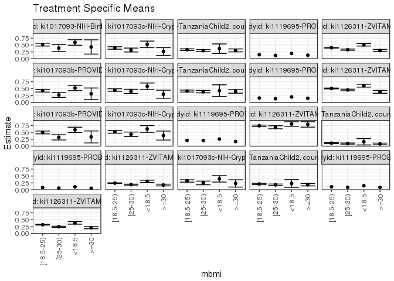

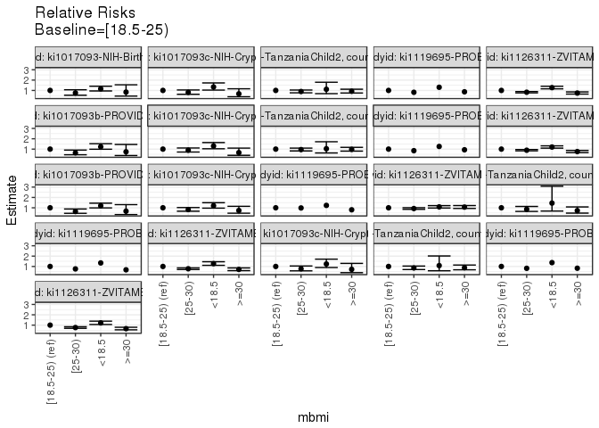

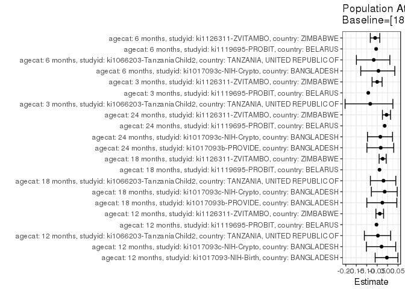

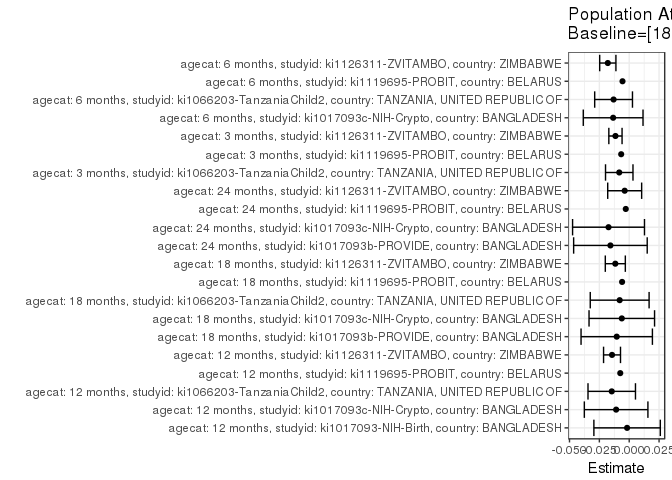

## Results Table

### Parameter: TSM

| agecat | studyid | country | intervention_level | baseline_level | estimate | ci_lower | ci_upper |
| --- | --- | --- | --- | --- | --- | --- | --- |
| 3 months | ki1066203-TanzaniaChild2 | TANZANIA, UNITED REPUBLIC OF | [18.5-25) | NA | 0.1086780 | 0.0913021 | 0.1260539 |
| 3 months | ki1066203-TanzaniaChild2 | TANZANIA, UNITED REPUBLIC OF | <18.5 | NA | 0.1578947 | 0.0419326 | 0.2738568 |
| 3 months | ki1066203-TanzaniaChild2 | TANZANIA, UNITED REPUBLIC OF | [25-30) | NA | 0.0931174 | 0.0721897 | 0.1140452 |
| 3 months | ki1066203-TanzaniaChild2 | TANZANIA, UNITED REPUBLIC OF | >=30 | NA | 0.0787879 | 0.0497146 | 0.1078611 |
| 3 months | ki1119695-PROBIT | BELARUS | [18.5-25) | NA | 0.0793208 | NA | NA |
| 3 months | ki1119695-PROBIT | BELARUS | <18.5 | NA | 0.1062992 | NA | NA |
| 3 months | ki1119695-PROBIT | BELARUS | [25-30) | NA | 0.0606407 | NA | NA |
| 3 months | ki1119695-PROBIT | BELARUS | >=30 | NA | 0.0536193 | NA | NA |
| 3 months | ki1126311-ZVITAMBO | ZIMBABWE | [18.5-25) | NA | 0.2418418 | 0.2315965 | 0.2520870 |
| 3 months | ki1126311-ZVITAMBO | ZIMBABWE | <18.5 | NA | 0.3075435 | 0.2677626 | 0.3473244 |
| 3 months | ki1126311-ZVITAMBO | ZIMBABWE | [25-30) | NA | 0.1880342 | 0.1708614 | 0.2052070 |
| 3 months | ki1126311-ZVITAMBO | ZIMBABWE | >=30 | NA | 0.1730104 | 0.1421719 | 0.2038488 |
| 6 months | ki1017093c-NIH-Crypto | BANGLADESH | [18.5-25) | NA | 0.3205128 | 0.2782037 | 0.3628219 |
| 6 months | ki1017093c-NIH-Crypto | BANGLADESH | <18.5 | NA | 0.3970588 | 0.2806854 | 0.5134322 |
| 6 months | ki1017093c-NIH-Crypto | BANGLADESH | [25-30) | NA | 0.2484472 | 0.1816548 | 0.3152396 |
| 6 months | ki1017093c-NIH-Crypto | BANGLADESH | >=30 | NA | 0.2307692 | 0.0984484 | 0.3630901 |
| 6 months | ki1066203-TanzaniaChild2 | TANZANIA, UNITED REPUBLIC OF | [18.5-25) | NA | 0.2106179 | 0.1870360 | 0.2341998 |
| 6 months | ki1066203-TanzaniaChild2 | TANZANIA, UNITED REPUBLIC OF | <18.5 | NA | 0.2285714 | 0.0894250 | 0.3677179 |
| 6 months | ki1066203-TanzaniaChild2 | TANZANIA, UNITED REPUBLIC OF | [25-30) | NA | 0.1798561 | 0.1512958 | 0.2084164 |
| 6 months | ki1066203-TanzaniaChild2 | TANZANIA, UNITED REPUBLIC OF | >=30 | NA | 0.1850649 | 0.1416843 | 0.2284455 |
| 6 months | ki1119695-PROBIT | BELARUS | [18.5-25) | NA | 0.1079174 | NA | NA |
| 6 months | ki1119695-PROBIT | BELARUS | <18.5 | NA | 0.1480000 | NA | NA |
| 6 months | ki1119695-PROBIT | BELARUS | [25-30) | NA | 0.0884434 | NA | NA |
| 6 months | ki1119695-PROBIT | BELARUS | >=30 | NA | 0.0894085 | NA | NA |
| 6 months | ki1126311-ZVITAMBO | ZIMBABWE | [18.5-25) | NA | 0.3173298 | 0.3047124 | 0.3299472 |
| 6 months | ki1126311-ZVITAMBO | ZIMBABWE | <18.5 | NA | 0.3860104 | 0.3374409 | 0.4345798 |
| 6 months | ki1126311-ZVITAMBO | ZIMBABWE | [25-30) | NA | 0.2426995 | 0.2212931 | 0.2641060 |
| 6 months | ki1126311-ZVITAMBO | ZIMBABWE | >=30 | NA | 0.2090909 | 0.1710911 | 0.2470907 |
| 12 months | ki1017093-NIH-Birth | BANGLADESH | [18.5-25) | NA | 0.5119363 | 0.4614324 | 0.5624403 |
| 12 months | ki1017093-NIH-Birth | BANGLADESH | <18.5 | NA | 0.5913978 | 0.4913982 | 0.6913975 |

[output cut: 54 more lines]

### Parameter: E(Y)

| agecat | studyid | country | intervention_level | baseline_level | estimate | ci_lower | ci_upper |
| --- | --- | --- | --- | --- | --- | --- | --- |
| 3 months | ki1066203-TanzaniaChild2 | TANZANIA, UNITED REPUBLIC OF | NA | NA | 0.1003416 | 0.0881706 | 0.1125126 |
| 3 months | ki1119695-PROBIT | BELARUS | NA | NA | 0.0726023 | NA | NA |
| 3 months | ki1126311-ZVITAMBO | ZIMBABWE | NA | NA | 0.2303216 | 0.2219831 | 0.2386601 |
| 6 months | ki1017093c-NIH-Crypto | BANGLADESH | NA | NA | 0.3070652 | 0.2737175 | 0.3404129 |
| 6 months | ki1066203-TanzaniaChild2 | TANZANIA, UNITED REPUBLIC OF | NA | NA | 0.1975309 | 0.1808409 | 0.2142208 |
| 6 months | ki1119695-PROBIT | BELARUS | NA | NA | 0.1023077 | NA | NA |
| 6 months | ki1126311-ZVITAMBO | ZIMBABWE | NA | NA | 0.2994075 | 0.2891066 | 0.3097084 |
| 12 months | ki1017093-NIH-Birth | BANGLADESH | NA | NA | 0.5101664 | 0.4680034 | 0.5523294 |
| 12 months | ki1017093c-NIH-Crypto | BANGLADESH | NA | NA | 0.3799726 | 0.3447141 | 0.4152311 |
| 12 months | ki1066203-TanzaniaChild2 | TANZANIA, UNITED REPUBLIC OF | NA | NA | 0.3157355 | 0.2951053 | 0.3363658 |
| 12 months | ki1119695-PROBIT | BELARUS | NA | NA | 0.1409295 | NA | NA |
| 12 months | ki1126311-ZVITAMBO | ZIMBABWE | NA | NA | 0.3848752 | 0.3744012 | 0.3953492 |
| 18 months | ki1017093b-PROVIDE | BANGLADESH | NA | NA | 0.4162521 | 0.3768752 | 0.4556289 |
| 18 months | ki1017093c-NIH-Crypto | BANGLADESH | NA | NA | 0.4433566 | 0.4069178 | 0.4797954 |
| 18 months | ki1066203-TanzaniaChild2 | TANZANIA, UNITED REPUBLIC OF | NA | NA | 0.4050633 | 0.3795393 | 0.4305872 |
| 18 months | ki1119695-PROBIT | BELARUS | NA | NA | 0.1533617 | NA | NA |
| 18 months | ki1126311-ZVITAMBO | ZIMBABWE | NA | NA | 0.4957193 | 0.4830216 | 0.5084170 |
| 24 months | ki1017093b-PROVIDE | BANGLADESH | NA | NA | 0.4802065 | 0.4395469 | 0.5208662 |
| 24 months | ki1017093c-NIH-Crypto | BANGLADESH | NA | NA | 0.5015773 | 0.4626267 | 0.5405279 |
| 24 months | ki1119695-PROBIT | BELARUS | NA | NA | 0.2047550 | NA | NA |
| 24 months | ki1126311-ZVITAMBO | ZIMBABWE | NA | NA | 0.7346128 | 0.7123424 | 0.7568833 |

### Parameter: RR

| agecat | studyid | country | intervention_level | baseline_level | estimate | ci_lower | ci_upper |
| --- | --- | --- | --- | --- | --- | --- | --- |
| 3 months | ki1066203-TanzaniaChild2 | TANZANIA, UNITED REPUBLIC OF | [18.5-25) | [18.5-25) | 1.0000000 | 1.0000000 | 1.0000000 |
| 3 months | ki1066203-TanzaniaChild2 | TANZANIA, UNITED REPUBLIC OF | <18.5 | [18.5-25) | 1.4528672 | 0.6851692 | 3.0807329 |
| 3 months | ki1066203-TanzaniaChild2 | TANZANIA, UNITED REPUBLIC OF | [25-30) | [18.5-25) | 0.8568191 | 0.6502860 | 1.1289480 |
| 3 months | ki1066203-TanzaniaChild2 | TANZANIA, UNITED REPUBLIC OF | >=30 | [18.5-25) | 0.7249661 | 0.4849131 | 1.0838556 |
| 3 months | ki1119695-PROBIT | BELARUS | [18.5-25) | [18.5-25) | 1.0000000 | NA | NA |
| 3 months | ki1119695-PROBIT | BELARUS | <18.5 | [18.5-25) | 1.3401172 | NA | NA |
| 3 months | ki1119695-PROBIT | BELARUS | [25-30) | [18.5-25) | 0.7644995 | NA | NA |
| 3 months | ki1119695-PROBIT | BELARUS | >=30 | [18.5-25) | 0.6759801 | NA | NA |
| 3 months | ki1126311-ZVITAMBO | ZIMBABWE | [18.5-25) | [18.5-25) | 1.0000000 | 1.0000000 | 1.0000000 |
| 3 months | ki1126311-ZVITAMBO | ZIMBABWE | <18.5 | [18.5-25) | 1.2716726 | 1.1098469 | 1.4570939 |
| 3 months | ki1126311-ZVITAMBO | ZIMBABWE | [25-30) | [18.5-25) | 0.7775092 | 0.7030448 | 0.8598607 |
| 3 months | ki1126311-ZVITAMBO | ZIMBABWE | >=30 | [18.5-25) | 0.7153867 | 0.5956254 | 0.8592282 |
| 6 months | ki1017093c-NIH-Crypto | BANGLADESH | [18.5-25) | [18.5-25) | 1.0000000 | 1.0000000 | 1.0000000 |
| 6 months | ki1017093c-NIH-Crypto | BANGLADESH | <18.5 | [18.5-25) | 1.2388235 | 0.8982727 | 1.7084831 |
| 6 months | ki1017093c-NIH-Crypto | BANGLADESH | [25-30) | [18.5-25) | 0.7751553 | 0.5745368 | 1.0458264 |
| 6 months | ki1017093c-NIH-Crypto | BANGLADESH | >=30 | [18.5-25) | 0.7200000 | 0.3997591 | 1.2967809 |
| 6 months | ki1066203-TanzaniaChild2 | TANZANIA, UNITED REPUBLIC OF | [18.5-25) | [18.5-25) | 1.0000000 | 1.0000000 | 1.0000000 |
| 6 months | ki1066203-TanzaniaChild2 | TANZANIA, UNITED REPUBLIC OF | <18.5 | [18.5-25) | 1.0852420 | 0.5843977 | 2.0153234 |
| 6 months | ki1066203-TanzaniaChild2 | TANZANIA, UNITED REPUBLIC OF | [25-30) | [18.5-25) | 0.8539449 | 0.7031482 | 1.0370815 |
| 6 months | ki1066203-TanzaniaChild2 | TANZANIA, UNITED REPUBLIC OF | >=30 | [18.5-25) | 0.8786761 | 0.6776570 | 1.1393252 |
| 6 months | ki1119695-PROBIT | BELARUS | [18.5-25) | [18.5-25) | 1.0000000 | NA | NA |
| 6 months | ki1119695-PROBIT | BELARUS | <18.5 | [18.5-25) | 1.3714189 | NA | NA |
| 6 months | ki1119695-PROBIT | BELARUS | [25-30) | [18.5-25) | 0.8195469 | NA | NA |
| 6 months | ki1119695-PROBIT | BELARUS | >=30 | [18.5-25) | 0.8284902 | NA | NA |
| 6 months | ki1126311-ZVITAMBO | ZIMBABWE | [18.5-25) | [18.5-25) | 1.0000000 | 1.0000000 | 1.0000000 |
| 6 months | ki1126311-ZVITAMBO | ZIMBABWE | <18.5 | [18.5-25) | 1.2164329 | 1.0660558 | 1.3880221 |
| 6 months | ki1126311-ZVITAMBO | ZIMBABWE | [25-30) | [18.5-25) | 0.7648181 | 0.6942893 | 0.8425115 |
| 6 months | ki1126311-ZVITAMBO | ZIMBABWE | >=30 | [18.5-25) | 0.6589073 | 0.5470532 | 0.7936319 |
| 12 months | ki1017093-NIH-Birth | BANGLADESH | [18.5-25) | [18.5-25) | 1.0000000 | 1.0000000 | 1.0000000 |
| 12 months | ki1017093-NIH-Birth | BANGLADESH | <18.5 | [18.5-25) | 1.1552176 | 0.9498262 | 1.4050230 |

[output cut: 54 more lines]

### Parameter: PAR

| agecat | studyid | country | intervention_level | baseline_level | estimate | ci_lower | ci_upper |
| --- | --- | --- | --- | --- | --- | --- | --- |
| 3 months | ki1066203-TanzaniaChild2 | TANZANIA, UNITED REPUBLIC OF | [18.5-25) | NA | -0.0083364 | -0.0198320 | 0.0031591 |
| 3 months | ki1119695-PROBIT | BELARUS | [18.5-25) | NA | -0.0067185 | NA | NA |
| 3 months | ki1126311-ZVITAMBO | ZIMBABWE | [18.5-25) | NA | -0.0115202 | -0.0170576 | -0.0059827 |
| 6 months | ki1017093c-NIH-Crypto | BANGLADESH | [18.5-25) | NA | -0.0134476 | -0.0384604 | 0.0115652 |
| 6 months | ki1066203-TanzaniaChild2 | TANZANIA, UNITED REPUBLIC OF | [18.5-25) | NA | -0.0130871 | -0.0289089 | 0.0027347 |
| 6 months | ki1119695-PROBIT | BELARUS | [18.5-25) | NA | -0.0056097 | NA | NA |
| 6 months | ki1126311-ZVITAMBO | ZIMBABWE | [18.5-25) | NA | -0.0179223 | -0.0247149 | -0.0111296 |
| 12 months | ki1017093-NIH-Birth | BANGLADESH | [18.5-25) | NA | -0.0017700 | -0.0295816 | 0.0260417 |
| 12 months | ki1017093c-NIH-Crypto | BANGLADESH | [18.5-25) | NA | -0.0109562 | -0.0375753 | 0.0156630 |
| 12 months | ki1066203-TanzaniaChild2 | TANZANIA, UNITED REPUBLIC OF | [18.5-25) | NA | -0.0146305 | -0.0345051 | 0.0052442 |
| 12 months | ki1119695-PROBIT | BELARUS | [18.5-25) | NA | -0.0074921 | NA | NA |
| 12 months | ki1126311-ZVITAMBO | ZIMBABWE | [18.5-25) | NA | -0.0143825 | -0.0214736 | -0.0072915 |
| 18 months | ki1017093b-PROVIDE | BANGLADESH | [18.5-25) | NA | -0.0104495 | -0.0403263 | 0.0194273 |
| 18 months | ki1017093c-NIH-Crypto | BANGLADESH | [18.5-25) | NA | -0.0062048 | -0.0336386 | 0.0212291 |
| 18 months | ki1066203-TanzaniaChild2 | TANZANIA, UNITED REPUBLIC OF | [18.5-25) | NA | -0.0079802 | -0.0326165 | 0.0166561 |
| 18 months | ki1119695-PROBIT | BELARUS | [18.5-25) | NA | -0.0059586 | NA | NA |
| 18 months | ki1126311-ZVITAMBO | ZIMBABWE | [18.5-25) | NA | -0.0116318 | -0.0200147 | -0.0032490 |
| 24 months | ki1017093b-PROVIDE | BANGLADESH | [18.5-25) | NA | -0.0157284 | -0.0465302 | 0.0150734 |
| 24 months | ki1017093c-NIH-Crypto | BANGLADESH | [18.5-25) | NA | -0.0173144 | -0.0474237 | 0.0127949 |
| 24 months | ki1119695-PROBIT | BELARUS | [18.5-25) | NA | -0.0028823 | NA | NA |
| 24 months | ki1126311-ZVITAMBO | ZIMBABWE | [18.5-25) | NA | -0.0037916 | -0.0180024 | 0.0104192 |

### Parameter: PAF

| agecat | studyid | country | intervention_level | baseline_level | estimate | ci_lower | ci_upper |
| --- | --- | --- | --- | --- | --- | --- | --- |
| 3 months | ki1066203-TanzaniaChild2 | TANZANIA, UNITED REPUBLIC OF | [18.5-25) | NA | -0.0830805 | -0.2035492 | 0.0253299 |
| 3 months | ki1119695-PROBIT | BELARUS | [18.5-25) | NA | -0.0925384 | NA | NA |
| 3 months | ki1126311-ZVITAMBO | ZIMBABWE | [18.5-25) | NA | -0.0500177 | -0.0743115 | -0.0262733 |
| 6 months | ki1017093c-NIH-Crypto | BANGLADESH | [18.5-25) | NA | -0.0437940 | -0.1285031 | 0.0345566 |
| 6 months | ki1066203-TanzaniaChild2 | TANZANIA, UNITED REPUBLIC OF | [18.5-25) | NA | -0.0662533 | -0.1493361 | 0.0108237 |
| 6 months | ki1119695-PROBIT | BELARUS | [18.5-25) | NA | -0.0548320 | NA | NA |
| 6 months | ki1126311-ZVITAMBO | ZIMBABWE | [18.5-25) | NA | -0.0598591 | -0.0827816 | -0.0374218 |
| 12 months | ki1017093-NIH-Birth | BANGLADESH | [18.5-25) | NA | -0.0034694 | -0.0594931 | 0.0495919 |
| 12 months | ki1017093c-NIH-Crypto | BANGLADESH | [18.5-25) | NA | -0.0288341 | -0.1013440 | 0.0389019 |
| 12 months | ki1066203-TanzaniaChild2 | TANZANIA, UNITED REPUBLIC OF | [18.5-25) | NA | -0.0463377 | -0.1112141 | 0.0147511 |
| 12 months | ki1119695-PROBIT | BELARUS | [18.5-25) | NA | -0.0531617 | NA | NA |
| 12 months | ki1126311-ZVITAMBO | ZIMBABWE | [18.5-25) | NA | -0.0373693 | -0.0559667 | -0.0190995 |
| 18 months | ki1017093b-PROVIDE | BANGLADESH | [18.5-25) | NA | -0.0251038 | -0.0994715 | 0.0442337 |
| 18 months | ki1017093c-NIH-Crypto | BANGLADESH | [18.5-25) | NA | -0.0139950 | -0.0778065 | 0.0460386 |
| 18 months | ki1066203-TanzaniaChild2 | TANZANIA, UNITED REPUBLIC OF | [18.5-25) | NA | -0.0197011 | -0.0823777 | 0.0393461 |
| 18 months | ki1119695-PROBIT | BELARUS | [18.5-25) | NA | -0.0388530 | NA | NA |
| 18 months | ki1126311-ZVITAMBO | ZIMBABWE | [18.5-25) | NA | -0.0234646 | -0.0405266 | -0.0066824 |
| 24 months | ki1017093b-PROVIDE | BANGLADESH | [18.5-25) | NA | -0.0327534 | -0.0989880 | 0.0294893 |
| 24 months | ki1017093c-NIH-Crypto | BANGLADESH | [18.5-25) | NA | -0.0345199 | -0.0963936 | 0.0238620 |
| 24 months | ki1119695-PROBIT | BELARUS | [18.5-25) | NA | -0.0140766 | NA | NA |
| 24 months | ki1126311-ZVITAMBO | ZIMBABWE | [18.5-25) | NA | -0.0051614 | -0.0246963 | 0.0140011 |